# Setup Notebook

```r
knitr::opts_knit$set(root.dir = '..')
devtools::install_github("tidyverse/ggplot2") #version with stat_qq_line
```

```r
# Load requirements
library(dplyr)
library(tidyr)
library(ggplot2)
```

# How much data is available?

```r
# Load data
data <- read.csv('outputs/encoded_data_2010.csv')
data <- data %>% mutate_if(is.integer,as.numeric)
print(dim(data))
```

```
[1] 18175   356
```

# How much data is missing?

Prior to this analysis, the dataset was already wrangled and variables with more than 1500 missing values were not selected. As a sanity check, I made sure the wrangled dataset does not contain too many missing values.

```
[1] \Total Cells: 2935935\
```

`r`r print(paste(‘Total Missing Cells’, sum(is.na(features)), sep=‘:’))

```
[1] \Total Missing Cells: 129179\
```

`r`r print(paste(‘Proportation of Cells Missing’, sum(is.na(features))/(18465*159), sep=‘:’))

```
[1] \Proportation of Cells Missing: 0.0439992711010291\
```

Only 4.4% of the cells are missing. Next, I want to know which columns have the most missing values. Given that this dataset was already wrangled, no column should have more than 1500 missing values.

`r`r for(column in names(features)){ print(paste(column, sum(is.na(select(features, column))), sep=‘:’)) }

```
[1] \lowest_grade: 0\
[1] \highest_grade: 0\
[1] \total_students: 242\
[1] \metro_micro: 28\
[1] \bureau_indian_education: 26\
[1] \charter_status: 26\
[1] \total_schools: 26\
[1] \english_language_learners: 242\
[1] \local_revenue_parent_government_contributions: 255\
[1] \local_revenue_property_tax: 299\
[1] \local_revenue_sales_tax: 299\
[1] \local_revenue_utilities_tax: 299\
[1] \local_revenue_income_tax: 299\
[1] \local_revenue_other_tax: 299\
[1] \teachers_elementary: 448\
```

[output cut: 140 more lines]

# How much data is not applicable?

During data wrangling, values that were “not applicable” were assigned zero. Certain features that only apply to a few school districts would have many zeros.

`r`r for(column in names(numerical_features)){ subset <- features[!is.na(select(features, column)), column] zeros <- sum(subset==0) print(paste(column, zeros, sep=‘:’)) }

```
[1] \total_students: 2092\
[1] \total_schools: 1456\
[1] \english_language_learners: 8054\
[1] \local_revenue_parent_government_contributions: 17104\
[1] \local_revenue_property_tax: 5912\
[1] \local_revenue_sales_tax: 17317\
[1] \local_revenue_utilities_tax: 16930\
[1] \local_revenue_income_tax: 17209\
[1] \local_revenue_other_tax: 15483\
[1] \teachers_elementary: 3031\
[1] \teachers_secondary: 4147\
[1] \teachers_ungraded: 10903\
[1] \teachers_total: 1862\
[1] \administrators_district: 3570\
[1] \administrators_school: 3867\
```

[output cut: 135 more lines]

Observations:

- There are over 2,000 school districts with total_students==0.
- There are 1,456 school districts with total_schools==0
- Aggregated features generally had fewer zeros than specific features (i.e. total_local_revenue had fewer zeros than state_revenue_staff_improvement)
- Lots of zeros in demographic data (more practical to just combine all minorities into a single feature)

Based on this, I decided to focus on the following numerical features:

1. total_students
2. total_schools
3. teachers_total
4. total_revenue
5. total_federal_revenue (as percentage of total_revenue)
6. total_state_revenue (as percentage of total_revenue)
7. total_local_revenue (as percentage of total_revenue)
8. total_expenditure
9. total_salaries
10. minority_students (as percentage of total_students)
11. male_students (opposite of total female students, created from summing demographic data, as percentage of total_students)

`r`r data_subset <- data %>% mutate(male_students = american_indian_alaskan_native_male_students + asian_hawaiian_native_pacific_islander_male_students + hispanic_male_students + black_non_hispanic_male_students + white_male_students + hawaiian_native_pacific_islander_male_students + mixed_race_male_students) %>% select(total_students, total_schools, teachers_total, total_revenue, total_federal_revenue, total_state_revenue, total_local_revenue, total_expenditure, total_salaries, white_students, male_students, exist_five_years) %>% mutate(total_revenue = total_federal_revenue + total_state_revenue + total_local_revenue, total_federal_revenue = total_federal_revenue / total_revenue, total_state_revenue = total_state_revenue / total_revenue, total_local_revenue = total_local_revenue / total_revenue, minority_students = 1 - white_students / total_students, male_students = male_students / total_students) data_subset[!is.na(data_subset$total_revenue) & data_subset$total_revenue == 0, c(‘total_federal_revenue’, ‘total_state_revenue’, ‘total_local_revenue’)] <- 0 data_subset[!is.na(data_subset$total_students) & data_subset$total_students == 0, c(‘minority_students’, ‘male_students’)] <- NA

# How are numerical variables distributed?

Given the size of the dataset (~18000 observations), statistical tests for normality would not work (always reject null hypothesis). Instead, I visually inspected q-q plots to determine normality.

`r`r for(feature in names(data_subset)){ if (feature != ‘exist_five_years’){ qqplot_obj <- ggplot(data_subset, aes_string(sample=feature)) + stat_qq() + stat_qq_line() ggsave(paste(‘output/plots/’, feature, ’_qqplot.png’, sep=’’), qqplot_obj) } }

The q-q plots are saved in the ‘output/plots’ folder. Here are the observations made from visual inspection.

#### total_local_revenue, total_state_revenue, total_federal_revenue, teachers_total, total_expenditure, total_revenue, total_salaries, total_schools, and total_students are positively skewed.

`r`r ggplot(data_subset, aes(sample=total_students)) + stat_qq() + stat_qq_line()

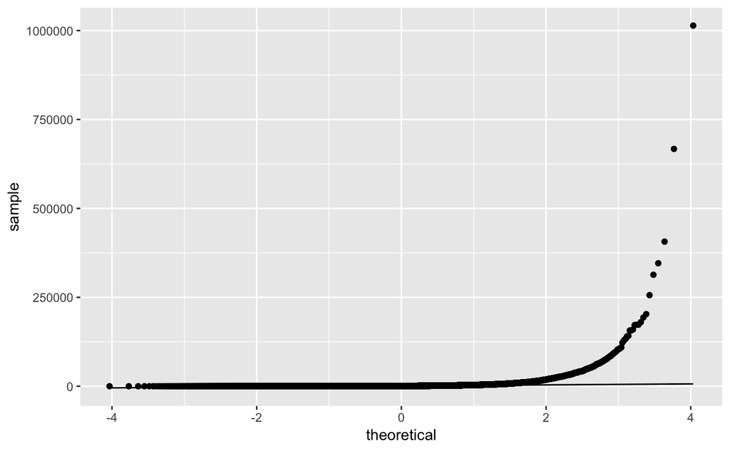

The positive skew suggests that the data may be lognormally distributed. I performed a log transformation on total_students, and plotted a q-q plot to verify.

`r`r ggplot(log(select(data_subset, total_students)), aes(sample=total_students)) + stat_qq() + stat_qq_line()

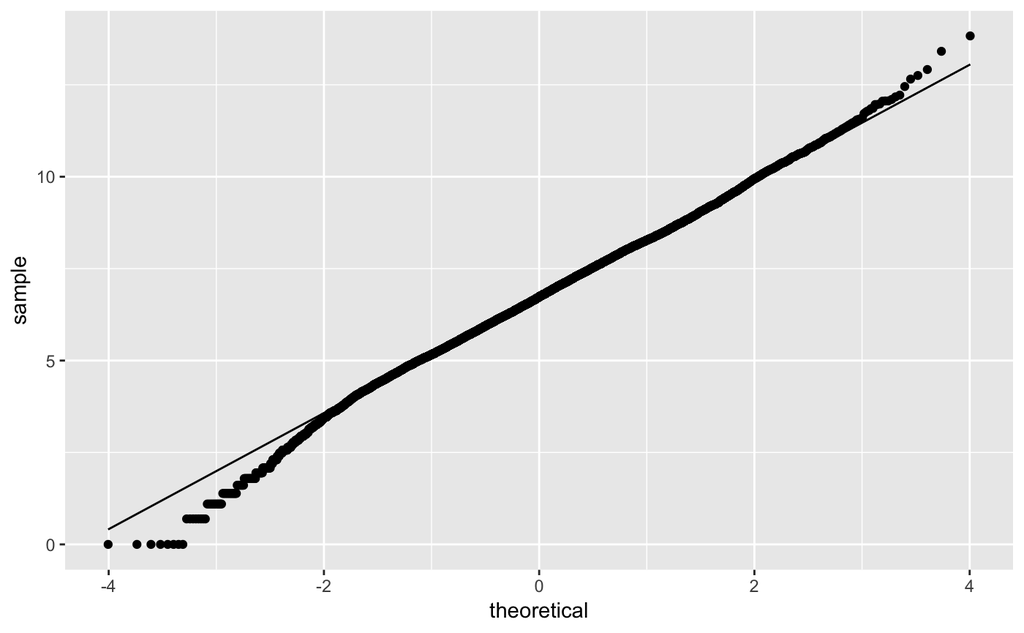

After the log transformation, total_students seemed much closer to normal distribution with long tails on both sides. Based on the previous observation that other numerical features displayed similar characteristics in q-q plots, I concluded that other numerical features are lognormally distributed as well.

#### male_students displayed heavy tails

`r`r ggplot(data_subset, aes(sample=male_students)) + stat_qq() + stat_qq_line()

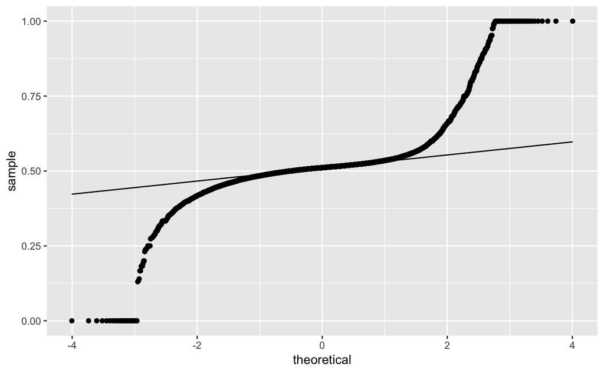

#### white_students is bi-modally distributed

`r`r ggplot(data_subset, aes(sample=white_students)) + stat_qq() + stat_qq_line()

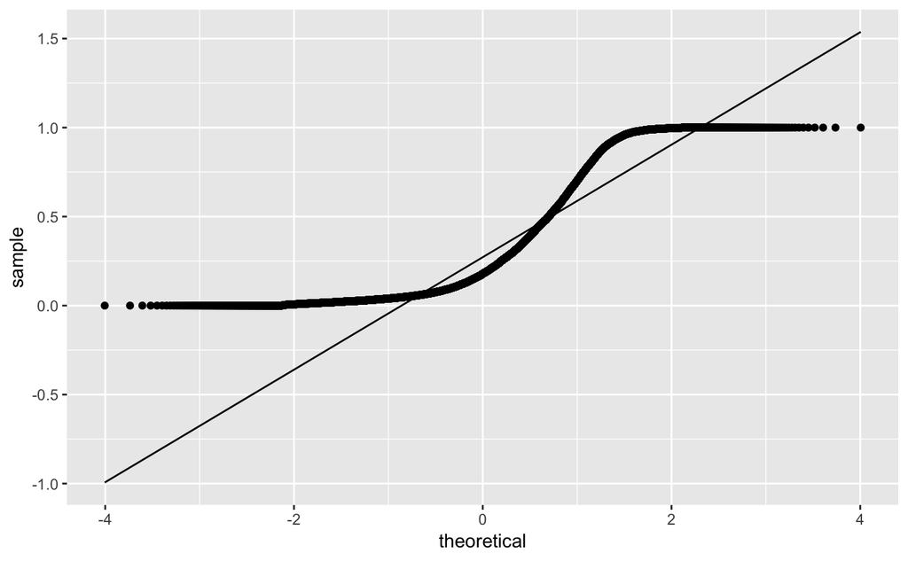

# Which variables are correlated with whether school district is at-risk?

I performed 2-sample t-tests on bootstrap samples of each numerical feature.

H_0: Mean of at-risk school districts is not significantly different than mean of non at-risk school districts H_a: Mean of at-risk school districts is significantly different than mean of non at-risk school districts

if(feature != ‘exist_five_years’){ print(feature) print(t.test(norisk_sample, atrisk_sample)) } }

```
[1] \total_students\

    Welch Two Sample t-test

data:  norisk_sample and atrisk_sample
t = 7.2101, df = 502.25, p-value = 2.068e-12
alternative hypothesis: true difference in means is not equal to 0
95 percent confidence interval:
 1975.285 3454.995
sample estimates:
mean of x mean of y
 2909.666   194.526

[1] \total_schools\

    Welch Two Sample t-test

data:  norisk_sample and atrisk_sample
t = 5.7204, df = 943.42, p-value = 1.426e-08
alternative hypothesis: true difference in means is not equal to 0
95 percent confidence interval:
 2.073287 4.238713
sample estimates:
mean of x mean of y
    4.684     1.528

[1] \teachers_total\

    Welch Two Sample t-test

data:  norisk_sample and atrisk_sample
t = 5.452, df = 713.11, p-value = 6.868e-08
alternative hypothesis: true difference in means is not equal to 0
95 percent confidence interval:
 112.0153 238.0889
sample estimates:
mean of x mean of y
 201.6075   26.5554

[1] \total_revenue\
```

[output cut: 87 more lines]

```
mean of x mean of y
0.2901247 0.5839111

[1] \male_students\

    Welch Two Sample t-test

data:  norisk_sample and atrisk_sample
t = 0.24006, df = 750.44, p-value = 0.8103
alternative hypothesis: true difference in means is not equal to 0
95 percent confidence interval:
 -0.01003338  0.01282915
sample estimates:
mean of x mean of y
0.5131386 0.5117407
```

Using a significant level of 0.01, the significant features are…

- total_students
- total_schools
- teachers_total
- total_revenue
- total_federal_revenue
- total_state_revenue
- total_local_revenue
- total_expenditure
- total_salaries
- minority_students

It is also important to note that federal revenue, although significant, was less significant than state an local revenue. The only non-significant feature was male_students.

# How are categorical variables distributed?

To visualize the distribution of categorical data, I created bar charts with the count of school districts in different categories.

`r`r for (feature in names(categorical_feature)){ barplot_obj <- ggplot(categorical_feature, aes_string(x=feature)) + geom_bar() ggsave(paste(‘output/plots/’, feature, ’_barplot.png’, sep=’’), barplot_obj) }

The bar plots are saved in the ‘output/plots’ folder. From visual inspection, none of the categorical features were evenly distributed between classes. The most frequent class in each categorical feature are…

- bureau_indian_education: 2 (no)
- charter_status: 3 (All associated schools are non-charter schools)
- highest_grade: 12
- lowest_grade: PK (Pre-kindergarten)
- metro_micro: 1 (metropolitan area)

# Which categorical variables are correlated with whether school district is at-risk?

I performed chi-squared tests on each categorical feature with exist_five_years.

H_0: There is no association between the categorical feature and whether the school is at-risk. H_a: There is association between the categorical feature and whether the school is at-risk.

`r`r for (feature in names(categorical_feature)){ print(feature) print(chisq.test(data[, feature], data$exist_five_years)) }

```
[1] \lowest_grade\
Chi-squared approximation may be incorrect

    Pearson's Chi-squared test

data:  data[, feature] and data$exist_five_years
X-squared = 1210.6, df = 16, p-value < 2.2e-16

[1] \highest_grade\
Chi-squared approximation may be incorrect

    Pearson's Chi-squared test

data:  data[, feature] and data$exist_five_years
X-squared = 1090.4, df = 16, p-value < 2.2e-16

[1] \metro_micro\

    Pearson's Chi-squared test

data:  data[, feature] and data$exist_five_years
X-squared = 60.137, df = 2, p-value = 8.738e-14

[1] \bureau_indian_education\
Chi-squared approximation may be incorrect

    Pearson's Chi-squared test with Yates' continuity correction

data:  data[, feature] and data$exist_five_years
X-squared = 0.018184, df = 1, p-value = 0.8927

[1] \charter_status\

    Pearson's Chi-squared test

data:  data[, feature] and data$exist_five_years
X-squared = 2474.3, df = 3, p-value < 2.2e-16
```

Using a significance level of 0.01, the significant features are…

- lowest_grade
- highest_grade
- metro_micro
- charter_status

Note: The warnings were due to imbalanced classes, but do not affect the overall conclusion.